# Report for noisette_antacosti

## 1. The Data

Here is your dataset as we reprocessed it. Please take a look.

**Click to see the clean data**

```r
#
 study_data |>
          kable( format = "html") %>%
          kable_styling(position = "center", full_width = F, bootstrap_options = c("striped","hover"))%>%
          scroll_box( width = "1000px", height = "500px", fixed_thead = T)
```

| Entry | Study | Region | Site | Depth.m | Sample.Year | Sample.Month | Sample.Day | Latitude | Longitude | Taxon | Fixed.or.Random | Sample.Unit.Size.sq.m | Percent.Cover | Stipe.Density.num.per.sq.m | Individual.Density.num.per.sq.m | Biomass.kg.wet.per.sq.m |
| --- | --- | --- | --- | --- | --- | --- | --- | --- | --- | --- | --- | --- | --- | --- | --- | --- |
| 1 | noisette_antacosti | Gulf of Saint Lawrence | PSO | NA | 2021 | 9 | 1 | 49.39483 | -63.59241 | Agarum clathratum | Fixed | 0.5 | NA | 3.7777778 | 3.7777778 | 0.0000000 |
| 2 | noisette_antacosti | Gulf of Saint Lawrence | PSO | NA | 2021 | 9 | 1 | 49.39483 | -63.59241 | Alaria esculenta | Fixed | 0.5 | NA | 1.0000000 | 1.0000000 | 0.0000000 |
| 4 | noisette_antacosti | Gulf of Saint Lawrence | PSO | NA | 2021 | 9 | 1 | 49.39483 | -63.59241 | Laminaria digitata | Fixed | 0.5 | NA | 0.3333333 | 0.3333333 | 0.0000000 |
| 7 | noisette_antacosti | Gulf of Saint Lawrence | PSO | NA | 2021 | 9 | 1 | 49.39483 | -63.59241 | Saccharina latissima | Fixed | 0.5 | NA | 12.0277778 | 12.0277778 | 0.0000000 |
| 9 | noisette_antacosti | Gulf of Saint Lawrence | RL | NA | 2021 | 9 | 1 | 49.60325 | -63.79761 | Agarum clathratum | Fixed | 0.5 | NA | 0.0000000 | 0.0000000 | 0.0000000 |
| 10 | noisette_antacosti | Gulf of Saint Lawrence | RL | NA | 2021 | 9 | 1 | 49.60325 | -63.79761 | Alaria esculenta | Fixed | 0.5 | NA | 0.5000000 | 0.5000000 | 0.0000000 |
| 12 | noisette_antacosti | Gulf of Saint Lawrence | RL | NA | 2021 | 9 | 1 | 49.60325 | -63.79761 | Laminaria digitata | Fixed | 0.5 | NA | 3.6666667 | 3.6666667 | 0.0000000 |
| 15 | noisette_antacosti | Gulf of Saint Lawrence | RL | NA | 2021 | 9 | 1 | 49.60325 | -63.79761 | Saccharina latissima | Fixed | 0.5 | NA | 3.4166667 | 3.4166667 | 0.0000000 |
| 17 | noisette_antacosti | Gulf of Saint Lawrence | PAI_est | NA | 2021 | 9 | 1 | 49.78143 | -64.35881 | Agarum clathratum | Fixed | 0.5 | NA | 0.0000000 | 0.0000000 | 0.0000000 |
| 18 | noisette_antacosti | Gulf of Saint Lawrence | PAI_est | NA | 2021 | 9 | 1 | 49.78143 | -64.35881 | Alaria esculenta | Fixed | 0.5 | NA | 13.5555556 | 13.5555556 | 0.1260387 |
| 20 | noisette_antacosti | Gulf of Saint Lawrence | PAI_est | NA | 2021 | 9 | 1 | 49.78143 | -64.35881 | Laminaria digitata | Fixed | 0.5 | NA | 0.2222222 | 0.2222222 | 0.0150000 |
| 23 | noisette_antacosti | Gulf of Saint Lawrence | PAI_est | NA | 2021 | 9 | 1 | 49.78143 | -64.35881 | Saccharina latissima | Fixed | 0.5 | NA | 9.1111111 | 9.1111111 | 0.8106250 |
| 25 | noisette_antacosti | Gulf of Saint Lawrence | CAA_ouest_1 | NA | 2021 | 9 | 1 | 49.78259 | -64.33733 | Agarum clathratum | Fixed | 0.5 | NA | 0.0000000 | 0.0000000 | 0.0000000 |
| 26 | noisette_antacosti | Gulf of Saint Lawrence | CAA_ouest_1 | NA | 2021 | 9 | 1 | 49.78259 | -64.33733 | Alaria esculenta | Fixed | 0.5 | NA | 4.7500000 | 4.7500000 | 0.0525000 |
| 28 | noisette_antacosti | Gulf of Saint Lawrence | CAA_ouest_1 | NA | 2021 | 9 | 1 | 49.78259 | -64.33733 | Laminaria digitata | Fixed | 0.5 | NA | 0.7500000 | 0.7500000 | 0.0425000 |
| 31 | noisette_antacosti | Gulf of Saint Lawrence | CAA_ouest_1 | NA | 2021 | 9 | 1 | 49.78259 | -64.33733 | Saccharina latissima | Fixed | 0.5 | NA | 9.0000000 | 9.0000000 | 1.5100000 |
| 33 | noisette_antacosti | Gulf of Saint Lawrence | PB_ouest_1 | NA | 2021 | 9 | 1 | 49.78361 | -64.40780 | Agarum clathratum | Fixed | 0.5 | NA | 0.0000000 | 0.0000000 | 0.0000000 |
| 34 | noisette_antacosti | Gulf of Saint Lawrence | PB_ouest_1 | NA | 2021 | 9 | 1 | 49.78361 | -64.40780 | Alaria esculenta | Fixed | 0.5 | NA | 1.3333333 | 1.3333333 | 0.0133333 |
| 36 | noisette_antacosti | Gulf of Saint Lawrence | PB_ouest_1 | NA | 2021 | 9 | 1 | 49.78361 | -64.40780 | Laminaria digitata | Fixed | 0.5 | NA | 2.1666667 | 2.1666667 | 1.0266667 |
| 39 | noisette_antacosti | Gulf of Saint Lawrence | PB_ouest_1 | NA | 2021 | 9 | 1 | 49.78361 | -64.40780 | Saccharina latissima | Fixed | 0.5 | NA | 5.8333333 | 5.8333333 | 0.1433854 |
| 41 | noisette_antacosti | Gulf of Saint Lawrence | PO | NA | 2021 | 9 | 1 | 49.86607 | -64.52927 | Agarum clathratum | Fixed | 0.5 | NA | 0.0000000 | 0.0000000 | 0.0000000 |
| 42 | noisette_antacosti | Gulf of Saint Lawrence | PO | NA | 2021 | 9 | 1 | 49.86607 | -64.52927 | Alaria esculenta | Fixed | 0.5 | NA | 5.3333333 | 5.3333333 | 0.0000000 |
| 44 | noisette_antacosti | Gulf of Saint Lawrence | PO | NA | 2021 | 9 | 1 | 49.86607 | -64.52927 | Laminaria digitata | Fixed | 0.5 | NA | 17.3333333 | 17.3333333 | 0.0000000 |
| 47 | noisette_antacosti | Gulf of Saint Lawrence | PO | NA | 2021 | 9 | 1 | 49.86607 | -64.52927 | Saccharina latissima | Fixed | 0.5 | NA | 0.0000000 | 0.0000000 | 0.0000000 |
| 49 | noisette_antacosti | Gulf of Saint Lawrence | PS | NA | 2021 | 9 | 1 | 49.91710 | -64.42995 | Agarum clathratum | Fixed | 0.5 | NA | 0.0000000 | 0.0000000 | 0.0000000 |
| 50 | noisette_antacosti | Gulf of Saint Lawrence | PS | NA | 2021 | 9 | 1 | 49.91710 | -64.42995 | Alaria esculenta | Fixed | 0.5 | NA | 5.2222222 | 5.2222222 | 0.0777778 |
| 52 | noisette_antacosti | Gulf of Saint Lawrence | PS | NA | 2021 | 9 | 1 | 49.91710 | -64.42995 | Laminaria digitata | Fixed | 0.5 | NA | 0.0000000 | 0.0000000 | 0.0000000 |
| 55 | noisette_antacosti | Gulf of Saint Lawrence | PS | NA | 2021 | 9 | 1 | 49.91710 | -64.42995 | Saccharina latissima | Fixed | 0.5 | NA | 9.8888889 | 9.8888889 | 0.9255556 |
| 57 | noisette_antacosti | Gulf of Saint Lawrence | PAI_ouest | NA | 2022 | 6 | 29 | 49.77786 | -64.36682 | Agarum clathratum | Fixed | 0.5 | NA | 0.0000000 | 0.0000000 | 0.0000000 |
| 58 | noisette_antacosti | Gulf of Saint Lawrence | PAI_ouest | NA | 2022 | 6 | 29 | 49.77786 | -64.36682 | Alaria esculenta | Fixed | 0.5 | NA | 3.3777778 | 3.3777778 | 0.1555556 |

[output cut: 254 more lines]

Here is your dataset as where we have now summed across all kelp species and put into the KelpTime main database format.

**Click to see the data in kelptime format**

```r
#|
kelptime_study |>
         kable( format = "html") %>%
         kable_styling(position = "center", full_width = F, bootstrap_options = c("striped","hover"))%>%
         scroll_box( width = "1000px", height = "500px", fixed_thead = T)
```

| study | site | period | latitude | longitude | sample_unit_size_sq_m | sasdate | max_depth | mean_depth | min_depth | biomass_kg_wet_per_sq_m | stipe_density_num_per_sq_m | individual_density_num_per_sq_m | percent_cover | has_bm | has_sd | has_id | has_pc | use_which | focalKelp | focalUnit | geometry | ecoregion | province | realm | focal_std_by_ecoregion | focal_std_by_province | focal_std_by_realm | ln_focal_std_by_ecoregion | ln_focal_std_by_province | … |
| --- | --- | --- | --- | --- | --- | --- | --- | --- | --- | --- | --- | --- | --- | --- | --- | --- | --- | --- | --- | --- | --- | --- | --- | --- | --- | --- | --- | --- | --- | --- |
| noisette_antacosti | CAA_ouest_1 | 1 | 49.78259 | -64.33733 | 0.5 | 2021-09-01 | 9999 | 9999 | 9999 | 1.6050000 | 14.500000 | 14.500000 | NA | 23 | 23 | 23 | 0 | 1 | 1.6050000 | Biomass | c(-64.337332, 49.782592) | Gulf of St. Lawrence - Eastern Scotian Shelf | Cold Temperate Northwest Atlantic | Temperate Northern Atlantic | 1.1875530 | 0.0064401 | 0.0064401 | 0.1802803 | -4.108029 | … |
| noisette_antacosti | CAA_ouest_1 | 2 | 49.78262 | -64.33859 | 0.5 | 2022-07-08 | 9999 | 9999 | 9999 | 0.4914667 | 19.822222 | 19.822222 | NA | 23 | 23 | 23 | 0 | 1 | 0.4914667 | Biomass | c(-64.338588, 49.782619) | Gulf of St. Lawrence - Eastern Scotian Shelf | Cold Temperate Northwest Atlantic | Temperate Northern Atlantic | 0.3636403 | 0.0019720 | 0.0019720 | -0.9844616 | -4.425182 | … |
| noisette_antacosti | CAA_ouest_3 | 1 | 49.78171 | -64.34225 | 0.5 | 2022-07-07 | 9999 | 9999 | 9999 | 0.0888889 | 5.422222 | 5.422222 | NA | 23 | 23 | 23 | 0 | 1 | 0.0888889 | Biomass | c(-64.342253, 49.781709) | Gulf of St. Lawrence - Eastern Scotian Shelf | Cold Temperate Northwest Atlantic | Temperate Northern Atlantic | 0.0657696 | 0.0003567 | 0.0003567 | -2.5800576 | -4.570124 | … |
| noisette_antacosti | CAA_ouest_3 | 2 | 49.78244 | -64.34261 | 0.5 | 2023-08-17 | 9999 | 9999 | 9999 | 0.1348963 | 10.962963 | 10.962963 | NA | 23 | 23 | 23 | 0 | 1 | 0.1348963 | Biomass | c(-64.34260562, 49.7824434744444) | Gulf of St. Lawrence - Eastern Scotian Shelf | Cold Temperate Northwest Atlantic | Temperate Northern Atlantic | 0.0998109 | 0.0005413 | 0.0005413 | -2.2089954 | -4.552456 | … |
| noisette_antacosti | Gamache | 1 | 49.79287 | -64.33955 | 0.5 | 2022-07-06 | 9999 | 9999 | 9999 | 0.6470222 | 12.622222 | 12.622222 | NA | 23 | 23 | 23 | 0 | 1 | 0.6470222 | Biomass | c(-64.339554, 49.792872) | Gulf of St. Lawrence - Eastern Scotian Shelf | Cold Temperate Northwest Atlantic | Temperate Northern Atlantic | 0.4787372 | 0.0025962 | 0.0025962 | -0.7159304 | -4.374359 | … |
| noisette_antacosti | Gamache | 2 | 49.79319 | -64.34038 | 0.5 | 2023-08-17 | 9999 | 9999 | 9999 | 1.0860259 | 13.074074 | 13.074074 | NA | 23 | 23 | 23 | 0 | 1 | 1.0860259 | Biomass | c(-64.3403756555556, 49.7931919777778) | Gulf of St. Lawrence - Eastern Scotian Shelf | Cold Temperate Northwest Atlantic | Temperate Northern Atlantic | 0.8035597 | 0.0043577 | 0.0043577 | -0.2063359 | -4.243467 | … |
| noisette_antacosti | LaTuque | 1 | 49.79323 | -64.35980 | 0.5 | 2022-07-01 | 9999 | 9999 | 9999 | 0.1694222 | 6.361616 | 6.361616 | NA | 23 | 23 | 23 | 0 | 1 | 0.1694222 | Biomass | c(-64.359801, 49.793227) | Gulf of St. Lawrence - Eastern Scotian Shelf | Cold Temperate Northwest Atlantic | Temperate Northern Atlantic | 0.1253569 | 0.0006798 | 0.0006798 | -1.9998401 | -4.539400 | … |
| noisette_antacosti | LaTuque | 2 | 49.79538 | -64.35972 | 0.5 | 2023-08-18 | 9999 | 9999 | 9999 | 1.2661704 | 40.370370 | 40.370370 | NA | 23 | 23 | 23 | 0 | 1 | 1.2661704 | Biomass | c(-64.3597182555556, 49.7953840755556) | Gulf of St. Lawrence - Eastern Scotian Shelf | Cold Temperate Northwest Atlantic | Temperate Northern Atlantic | 0.9368501 | 0.0050806 | 0.0050806 | -0.0546145 | -4.194348 | … |
| noisette_antacosti | PAI_est | 1 | 49.78143 | -64.35881 | 0.5 | 2021-09-01 | 9999 | 9999 | 9999 | 0.9516637 | 22.888889 | 22.888889 | NA | 23 | 23 | 23 | 0 | 1 | 0.9516637 | Biomass | c(-64.358808, 49.781426) | Gulf of St. Lawrence - Eastern Scotian Shelf | Cold Temperate Northwest Atlantic | Temperate Northern Atlantic | 0.7041440 | 0.0038186 | 0.0038186 | -0.3366706 | -4.281740 | … |
| noisette_antacosti | PAI_est | 2 | 49.78118 | -64.35800 | 0.5 | 2022-07-02 | 9999 | 9999 | 9999 | 0.3478222 | 11.555556 | 11.555556 | NA | 23 | 23 | 23 | 0 | 1 | 0.3478222 | Biomass | c(-64.357998, 49.781177) | Gulf of St. Lawrence - Eastern Scotian Shelf | Cold Temperate Northwest Atlantic | Temperate Northern Atlantic | 0.2573566 | 0.0013957 | 0.0013957 | -1.3191720 | -4.474523 | … |
| noisette_antacosti | PB_est | 1 | 49.78354 | -64.39932 | 0.5 | 2022-06-30 | 9999 | 9999 | 9999 | 0.9848889 | 5.155556 | 5.155556 | NA | 23 | 23 | 23 | 0 | 1 | 0.9848889 | Biomass | c(-64.399317, 49.783542) | Gulf of St. Lawrence - Eastern Scotian Shelf | Cold Temperate Northwest Atlantic | Temperate Northern Atlantic | 0.7287276 | 0.0039519 | 0.0039519 | -0.3028260 | -4.272138 | … |
| noisette_antacosti | PB_est | 2 | 49.78369 | -64.39851 | 0.5 | 2023-08-24 | 9999 | 9999 | 9999 | 0.9650178 | 24.770370 | 24.770370 | NA | 23 | 23 | 23 | 0 | 1 | 0.9650178 | Biomass | c(-64.39851098, 49.7836857011111) | Gulf of St. Lawrence - Eastern Scotian Shelf | Cold Temperate Northwest Atlantic | Temperate Northern Atlantic | 0.7140248 | 0.0038722 | 0.0038722 | -0.3229297 | -4.277870 | … |
| noisette_antacosti | PS | 1 | 49.91710 | -64.42995 | 0.5 | 2021-09-01 | 9999 | 9999 | 9999 | 1.0033333 | 15.111111 | 15.111111 | NA | 23 | 23 | 23 | 0 | 1 | 1.0033333 | Biomass | c(-64.429945, 49.917103) | Gulf of St. Lawrence - Eastern Scotian Shelf | Cold Temperate Northwest Atlantic | Temperate Northern Atlantic | 0.7423748 | 0.0040259 | 0.0040259 | -0.2845207 | -4.266848 | … |
| noisette_antacosti | PS | 2 | 49.91710 | -64.42995 | 0.5 | 2023-08-20 | 9999 | 9999 | 9999 | 1.1096828 | 18.206897 | 18.206897 | NA | 23 | 23 | 23 | 0 | 1 | 1.1096828 | Biomass | c(-64.429945, 49.91710299) | Gulf of St. Lawrence - Eastern Scotian Shelf | Cold Temperate Northwest Atlantic | Temperate Northern Atlantic | 0.8210636 | 0.0044527 | 0.0044527 | -0.1850489 | -4.236877 | … |

## 2. Plots of raw data

### 2.1 By metric

Here is what your data looks like with all sites plotted together looking at each sampling metric.

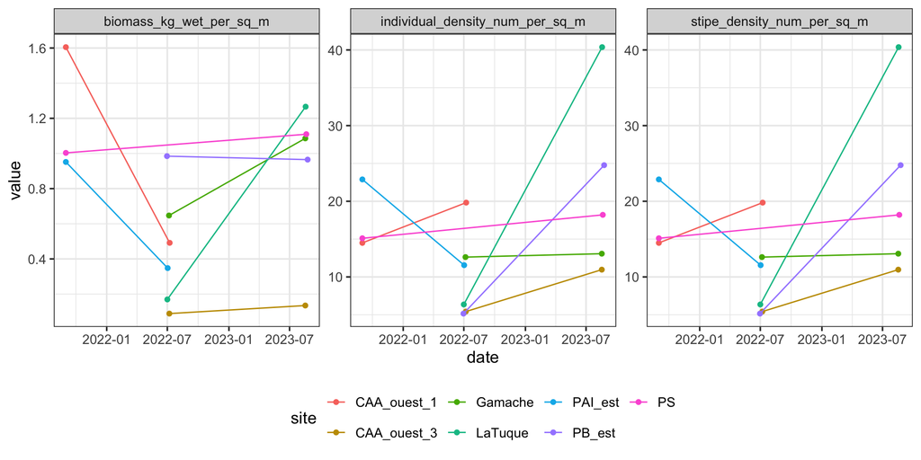

```r
kelptime_study_measurement_long <-
  kelptime_study |>
  tidyr::pivot_longer(cols =biomass_kg_wet_per_sq_m:percent_cover) |>
  filter(!is.na(value))

ggplot(kelptime_study_measurement_long,
       aes(x = date, y = value,
           color = site)) +
  geom_point() +
  geom_line() +
  facet_wrap(vars(name), scale = "free_y")
```

### 2.2 Standardized data

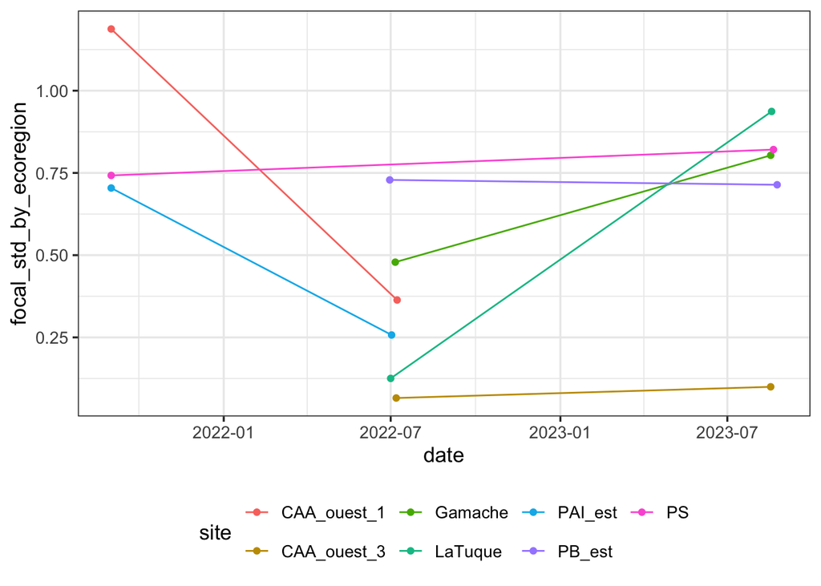

```r
ggplot(kelptime_study,
       aes(x = date, y = focal_std_by_ecoregion,
           color = site)) +
  geom_point() +
  geom_line()
```

### 2.3 Standardized data by site

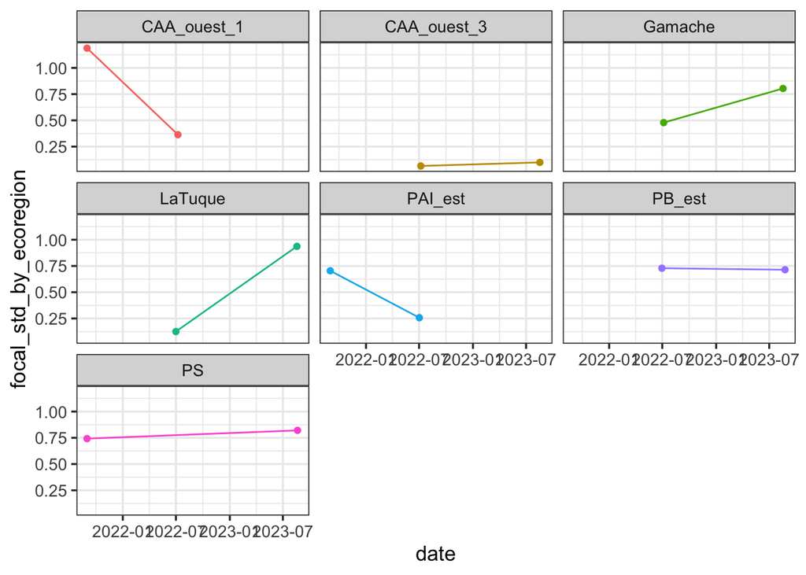

```r
ggplot(kelptime_study,
       aes(x = date, y = focal_std_by_ecoregion,
           color = site)) +
  geom_point() +
  geom_line() +
  facet_wrap(vars(site)) +
  guides(color = "none")
```

## 3. Modeled timeseries resuls

We fit two models. One where the slope varies by ecoregion (note: the GOSL and Newfoundland are collapsed) and one where the slope does not vary by ecoregion. Based on the modeled results, here is the smoothed fits to your data. Note - thus far, the model with a common slope appears to be the correct is the one with a common slope (best fit in terms of prediction and p-value for slope*ecoregion is not distinguishable from 0).

**Note** - the study (black) line might not line up in the middle or on trajectories, as it is shrunken in towards the grand mean for the ecoregion.

### 3.1 Slope Varying by Ecoregion Model

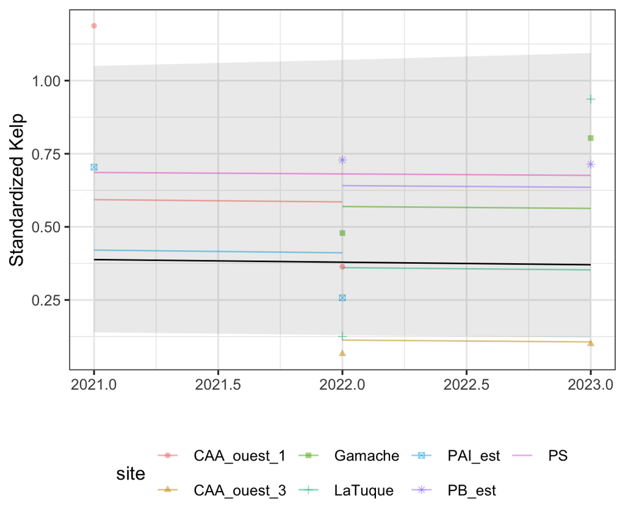

```r
mod_ecoregion <- readRDS("models/mod_ecoregion.rds")


# for plotting to do the back transform
exp_trans <- function(dat){

  dat |>
    mutate(
      Predicted = exp(Predicted)-0.01,
           CI_low = exp(CI_low)-0.01,
           CI_high = exp(CI_high)-0.01,
           CI_high = ifelse(CI_high>1.1, 1.1, CI_high)
    )|>
               mutate(trajectory =
                        gsub(study[1], "", trajectory))

}


re_ecoregion <- ranef(mod_ecoregion)$cond$study |>
  as_tibble(rownames = "study")  |>
  filter(study == params$study) |>
  pull(`(Intercept)`)


dat_fixed_ecoregion <- estimate_relation(mod_ecoregion,
                               include_random = FALSE,
                  length = 200,
                  data = kelptime_study) |>
  mutate(Predicted = Predicted + re_ecoregion,
         CI_high = CI_high + re_ecoregion,
         CI_low = CI_low + re_ecoregion) |>
  exp_trans()

dat_traj_ecoregion <- estimate_relation(mod_ecoregion,
                              include_random = TRUE,
                  length = 200,
                  data = kelptime_study) |>
    exp_trans()


ggplot(dat_traj_ecoregion, aes(x = year)) +
  geom_line(aes(y = Predicted,
                color = trajectory), alpha = 0.5) +
  geom_point(aes(y = focal_std_by_ecoregion,
                 group = trajectory,
                 shape = trajectory,
                 color = trajectory), alpha = 0.5,
             data = kelptime_study |>
               mutate(trajectory =
                        gsub(study[1], "", trajectory))) +
  geom_line(data = dat_fixed_ecoregion,
            aes(y = Predicted), color = "black") +
  geom_ribbon(data = dat_fixed_ecoregion,
            aes(y = Predicted,
                ymin = CI_low,
                ymax = CI_high), color = NA,
            alpha = 0.1) +
  labs(x = "", y = "Standardized Kelp",
      color = "site", shape = "site")
```

### 3.2 Common Slope Model

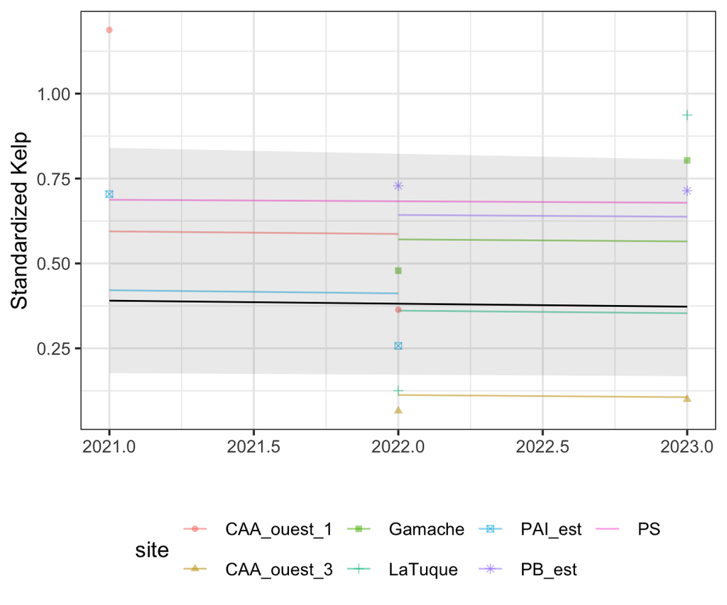

```r
mod_common_slope <- readRDS("models/mod_common_slope.rds")

re <- ranef(mod_common_slope)$cond$study |>
  as_tibble(rownames = "study")  |>
  filter(study == params$study) |>
  pull(`(Intercept)`)


dat_fixed <- estimate_relation(mod_common_slope,
                               include_random = FALSE,
                  length = 200,
                  data = kelptime_study) |>
  mutate(Predicted = Predicted + re,
         CI_high = CI_high + re_ecoregion,
         CI_low = CI_low + re_ecoregion) |>
  exp_trans()

dat_traj <- estimate_relation(mod_common_slope,
                              include_random = TRUE,
                  length = 200,
                  data = kelptime_study) |>
    exp_trans()

ggplot(dat_traj, aes(x = year)) +
  geom_line(aes(y = Predicted,
                color = trajectory), alpha = 0.5) +
  geom_point(aes(y = focal_std_by_ecoregion,
                 group = trajectory,
                 shape = trajectory,
                 color = trajectory), alpha = 0.5,
             data = kelptime_study |>
               mutate(trajectory =
                        gsub(study[1], "", trajectory))) +
  geom_line(data = dat_fixed,
            aes(y = Predicted), color = "black") +
  geom_ribbon(data = dat_fixed,
            aes(y = Predicted,
                ymin = CI_low,
                ymax = CI_high), color = NA,
            alpha = 0.1) +
  labs(x = "", y = "Standardized Kelp",
      color = "site", shape = "site")
```